## Estudo Contencioso

### Indicadores - Predict 2017

Baseado no Guide to measuring the Information Society (Organisation for Economic Co-operation and Development, OECD 2011).

Comparatibilidade utilizando NACE-Rev.2.1 (1995 - 2014)

1. **Business R&D Expenditure (BERD)**: Intramural expenditures on R&D performed within business enterprise sector during a specific period, whatever the source of funds (Frascati Manual). Business enterprise expenditure on R&D (BERD) -covers R&D activities carried out in the business -sector by performing firms and institutes, regardless of the origin of funding.
2. **Gross R&D Expenditure (GERD)**: Gross domestic expenditure on research and development (GERD) is total intramural expenditure on research and development performed on the national territory during a given period. Gross domestic spending on R&D is defined as the total expenditure (current and capital) on R&D carried out by all resident companies, research institutes, university and government laboratories, etc., in a country. It includes R&D funded from abroad, but excludes domestic funds for R&D performed outside the domestic economy. This indicator is measured in million USD and as percentage of GDP
3. **R&D personnel (PERD)**: For statistical purposes, indicators on R & D personnel are compiled as both head counts (HC) and as full-time equivalents (FTEs). Researchers are a subcategory of R & D personnel and are professionals engaged in the conception or creation of new knowledge, products, processes, methods and systems, and in the management of the projects concerned.
4. **R&D researchers (RERD)**
5. **Gross Value Added (GVA)**: is the measure of the value of goods and services produced in an area, industry or sector of an economy, in economics. In national accounts GVA is output minus intermediate consumption;[1] it is a balancing item of the national accounts’ production account.[2]
6. **Gross Output (GO)**
7. **Employment (EMP)**
8. **Hours worked (HEMP)**
9. **Labour productivity per employed person (PRODEMP)**
10. **Labour productivity per hour worked (PRODHEMP)**
11. Government budget allocations for R&D (GBARD) for the period 2006-2015.**Não disponível para o Brazil**
12. Government budget allocations for ICT R&D (ICT GBARD) for the period 2006-2015.**Não disponível para o Brazil**

### ICT sector - Comparatibilidade

The operational definition of the ICT sector provides information to maintain the comparability of countries over longer periods in cases where insufficient information is available to estimate the ICT subsectors of the comprehensive definition. This definition distinguishes between:

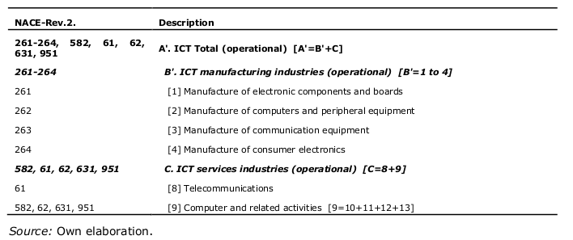

### Data sources

UE = Eurostat; OECD; SRD; SBS

BRAZIL = IBGE; UIS(UNESCO).

Brazil remarks:

*We have used PINTEC data by industry and correspondences between CNAE 2/CNAE 1 and NACE-Rev.2 to distribute R&D expenditure among ICT, RS and selected non-ICT sectors.

*Gross value of industrial production from Industrial Survey (IBGE) has been also used, in order to distribute the R&D expenditures between ICT Sector NACE 263 (Manufacture of communication equipment), 264 (Manufacture of consumer electronics) and 268 (Manufacture of magnetic and optical media). It has also been used to estimate NACE 303 (Manufacture of air and spacecraft and related machinery).

*ICT sector NACE 62 (Computer programming, consultancy and related activities) includes ICT sector NACE 582 (Software publishing). In addition, for Brazil there is no information for the MC sector (NACE 581, 59, 60 and 639), the ICT trade sector (NACE 465) and for one ICT services sector: 951 (Repair of computers and communication equipment)

*there is no available information on BERD at 4-digits NACE and ICT services sector’s data is only available for 2008 onwards. PINTEC 2000 and 2003 do not include information on services sectors.

*Brazil’s dataset does not contain information for RS sector (NACE 4791) and macro-sectors NACE 45 (Wholesale and retail trade and repair of motor vehicles and motorcycles), 85 (Education) and the aggregations 49-99 (Services, except trade), 45-47 (Wholesale and retail trade, repair of motor vehicles and motorcycles), 49-53 (Transportation and storage), 58-63 (Information and communication), 64-66 (Financial and insurance activities), 69-82 (Professional, scientific, technical, administration and support service activities), 69-75 (Professional, scientific and technical activities) and 86-88 (Human health and social work activities).Data for GERD come from UNESCO-UIS database. We obtain BERD in euros and PPS using exchange rates and purchasing power parities coming from OECD and Eurostat.

### Indicadores que serão analisados

**Faturamento**

**Empregos**

**Balança Comercial TICs**

**P&D**

**Produtividade**

### Perguntas norteadoras

Se NÃO tivese a L.I o que aconteceria com o aumento da importação?

Diminuiria ou aumentaria o emprego?

### Países escolhidos

*Critério: Países que foram analisados pelo Predict2017 e que apresentam incentivos R&D Tax de acordo com o Survey da Deloitte Brasil Coreia do Sul Estados Unidos Reino Unido China